# Warsztaty ggplot2

Paweł Koźmiński, Mateusz Grzyb

12/12/2019

## Zanim zaczniemy:

# Wprowadzenie

Pakiet `ggplot2` jest jednym z najbardziej zaawansowanych narzędzi stworzonych do wizualizacji danych w języku programowania R. Został wydany w 2007 roku przez Hadleya Wickhama. Biblioteka oparta jest na gramatyce, której budowę przedstawia poniższa grafika:

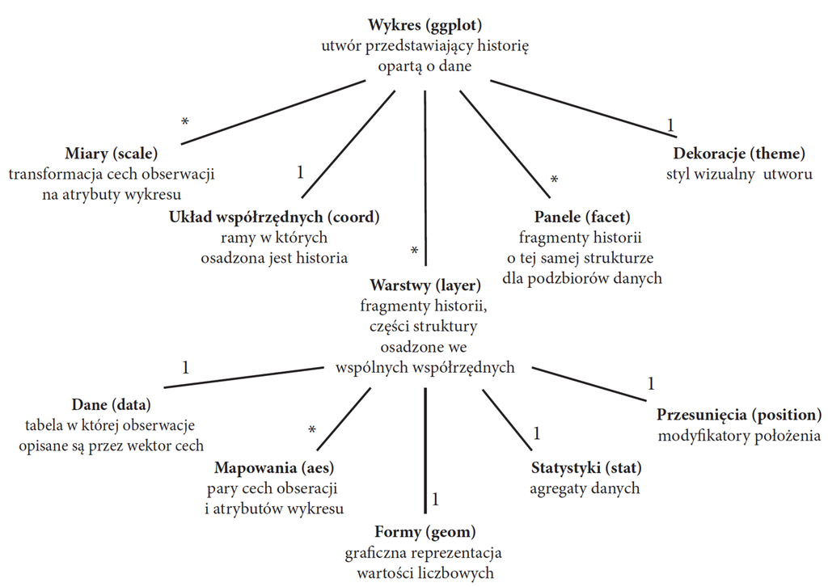

Na zajęciach postaramy się pokrótce zaprezentować Państwu wszystkie z powyższych struktur z naciskiem na przykłady użycia.

Na zajęciach będziemy operowali na zbiorze danych `countries` z pakietu `SmarterPoland`. W związku z tym, wczytajmy dane oraz wyświetlmy kilka wierszy:

```r
#install.packages("SmarterPoland")
library(SmarterPoland)
head(countries)
```

```
##               country birth.rate death.rate population continent
## 1         Afghanistan       34.1        7.7      30552      Asia
## 2             Albania       12.9        9.4       3173    Europe
## 3             Algeria       24.3        5.7      39208    Africa
## 4             Andorra        8.9        8.4         79    Europe
## 5              Angola       44.1       13.9      21472    Africa
## 6 Antigua and Barbuda       16.5        6.8         90  Americas
```